# FA Talk

Michael Clark

2018-02-10

## Thinking about FA

- Dimension Reduction
- Matrix Factorization
- Latent Linear Models
- Measurement error

## PCA

Seek to find orthogonal factors to minimize reconstruction error.

$$\mathscr{Loss} = X - ZW^T$$

X is the $NxD$ matrix of observed scores, $Z$ are the $N x L$ component scores where L < D, while $W$ are the $DxL$ weights, typically referred to as the factor loading matrix.

With all components

$$X = ZW^T$$

The MNIST data contains 28 by 28 pixel images of digits 0-9. If we unroll the data to 784 columns, each row represents a single digit. We can see in the following how well we can reconstruct a digit via PCA. Even with only two components we can get a sense of what we’re looking at. With all components the reconstruction is perfect.

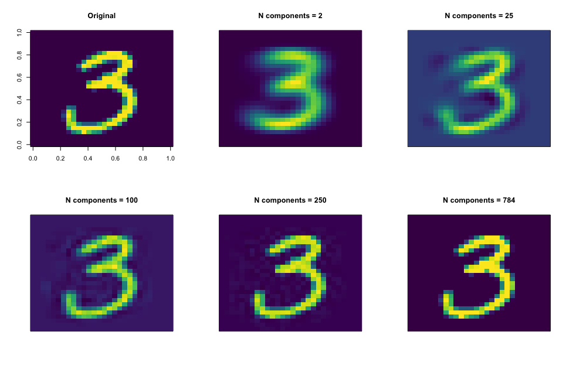

## FA

$$X \approx ZW^T$$

## FA for measurement

### “Confirmatory” Factor Analysis

## As latent linear models

### FA

$$X \sim \mathcal{N}(ZW^T + \mu, \Psi)$$
$\mu$ are the intercepts, $\Psi$ is a $DxD$ covariance matrix.

### Probabilistic PCA

For probabilistic PCA $\Psi$ is $\sigma^2I$.

### PCA

PCA $\sigma$ = 0,

## Count-based Matrix Factorization

Commonly our data regards counts or otherwise compositional data. In this case we can use techniques that are better suited to such data.

### NMF

Non-negative matrix factorization is similar to PCA, just with the constraint that scores be positive. It is (in the usual implementation) identical to probabilistic latent semantic analysis.

### LDA

Latent Dirichlet takes a different approach

Latent classes

- Mixture models
- Other cluster analysis

Other

- ICA
- Recommender systems
- Bayesian

## Issues

- how many factors?
- two step models vs. simultaneous estimation